# Customer Analytics and A/B Testing

Zhaowen Guo

## Identifying and understanding KPIs

Goal - comparing KPIs

- Goal: Examine the KPI “user conversion rate” after the free trial.
- Week One Conversion Rate: Limit to users who convert in their first week after the trial ends.

How to choose KPI metrics?

- How long does it take to determine?
  - Monthly Conversion Rate implies one-month wait time
- Leverage exploratory data analysis
  - Reveals relationship between metrics and key results
- Business goals

Understand conversion rate

- Maximum lapse date (date the trial ends for a given user)
- Restrict users by lapse date
- Restrict users by cohort
- Formula: conversion rate = # total subscriptions / # total users

```r
library(zoo)
library(pracma)
library(kableExtra)
library(tidyverse)
customer <- read.csv("data/user_demographics_v1.csv", stringsAsFactors = F)
purchase <- read.csv("data/purchase_data_v1.csv", stringsAsFactors = F)
revenue <- read.csv("data/daily_revenue.csv", stringsAsFactors = F)
paywall <- read.csv("data/user_demographics_paywall.csv", stringsAsFactors = F)
abtesting <- read.csv("data/AB_testing_exercise.csv", stringsAsFactors = F)
```

```r
purchase <- purchase %>%
    inner_join(customer, by = "uid")
```

```r
purchase %>%
    group_by(gender, device) %>%
    summarise(mean.price = mean(price),
              median.price = median(price)) %>%
    ungroup() %>%
    kable(col.names = c("Gender","Device","Mean","Median"))
```

| Gender | Device | Mean | Median |
| --- | --- | --- | --- |
| F | and | 400.7475 | 299 |
| F | iOS | 404.4353 | 299 |
| M | and | 416.2373 | 499 |
| M | iOS | 405.2724 | 299 |

```r
# compute KPI
current_date <- as.Date("2018-03-17")
max_purchase_date <- current_date - 28

# filter to purchases within the first 28 days of registration (convert within a month)
purchase$reg_date <- as.Date(purchase$reg_date)
purchase$date <- as.Date(purchase$date)
purchase_conversion <- purchase %>%
    filter(reg_date < max_purchase_date) %>%
    filter(date <= reg_date+28)
mean(purchase_conversion$price)
```

```
## [1] 414.4237
```

```r
# average purchase by cohort
max_reg_date <- current_date - 28
purchase_group <- purchase %>%
    filter(reg_date < max_reg_date) %>%
    filter(date < reg_date + 28) %>%
    group_by(gender, device) %>%
    summarise(mean.price = mean(price),
              median.price = median(price)) %>%
    ungroup() %>%
    kable(col.names = c("Gender","device","Mean","Median"))
purchase_group
```

| Gender | device | Mean | Median |
| --- | --- | --- | --- |
| F | and | 388.2045 | 299 |
| F | iOS | 432.5878 | 499 |
| M | and | 413.7059 | 399 |
| M | iOS | 433.3137 | 499 |

## Exploring Customer Behavior

Concepts in time series data

- Seasonality: trends following the day of the week
  - Potentially more likely to subscribe on the weekend
  - Seasonality may hide larger trends
- Correcting seasonality
  - Trailing average: smoothing technique that averages over a lagging window
    - Reveal hidden trends by smoothing out seasonality
    - Average across the period of seasonality
    - 7-day window to smooth weekly seasonality
    - Average out day-level effects to produce the average week effect
  - Exponential moving average: weighted moving average
    - Weights more recent items in the window more
    - Applies weights according to an exponential distribution
    - Averages back to a central trend without masking any recent movements

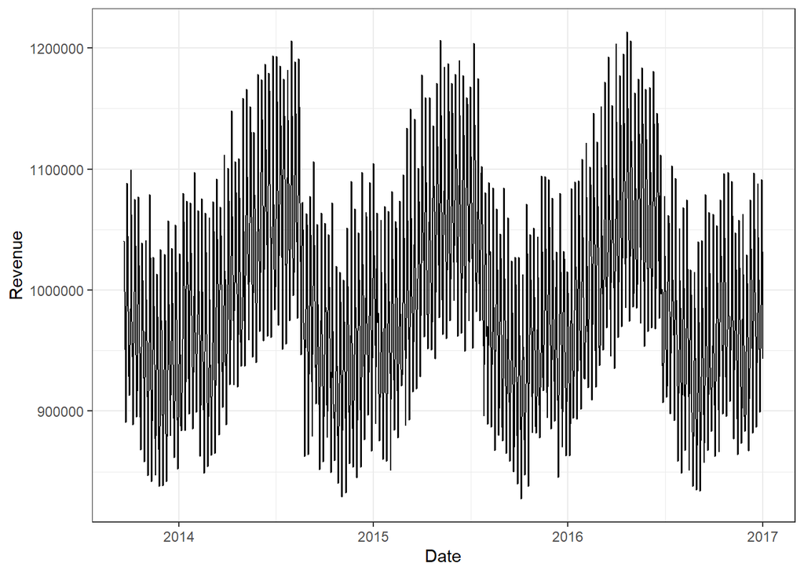

```r
revenue$date <- as.Date(revenue$date)
revenue_daily <- revenue %>%
    group_by(date) %>%
    summarise(sum.revenue = sum(revenue))

ggplot(revenue_daily, aes(x=date,y=sum.revenue)) +
    geom_line() +
    theme_bw() +
    labs(x="Date",y="Revenue")
```

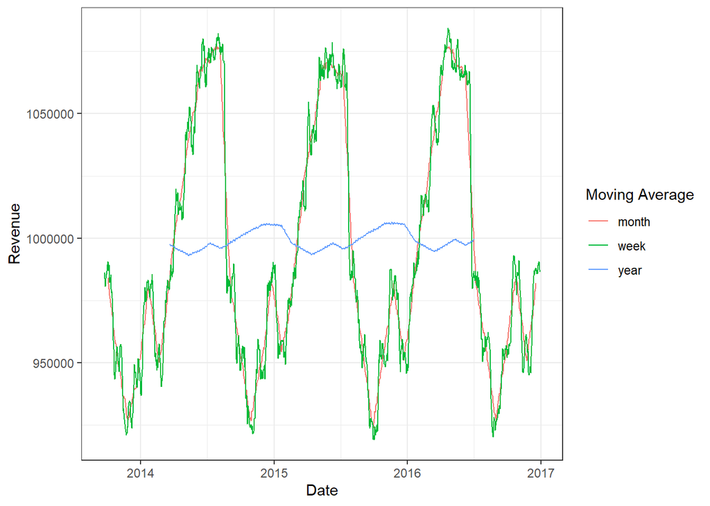

```r
revenue_daily <- revenue_daily %>%
    mutate(week = rollmean(sum.revenue, k=7, fill = NA),
           month = rollmean(sum.revenue, k=28, fill = NA),
           year = rollmean(sum.revenue, k=365, fill = NA))

revenue_compare <- revenue_daily %>%
    pivot_longer(names_to = "rolling_mean_key",
                 values_to = "rolling_mean_value",
                 cols = c(week, month, year))

ggplot(revenue_compare, aes(x=date,
                            y = rolling_mean_value,
                            color = rolling_mean_key)) +
    geom_line() +
    theme_bw() +
    labs(x="Date", y="Revenue") +
    scale_color_discrete(name = "Moving Average")
```

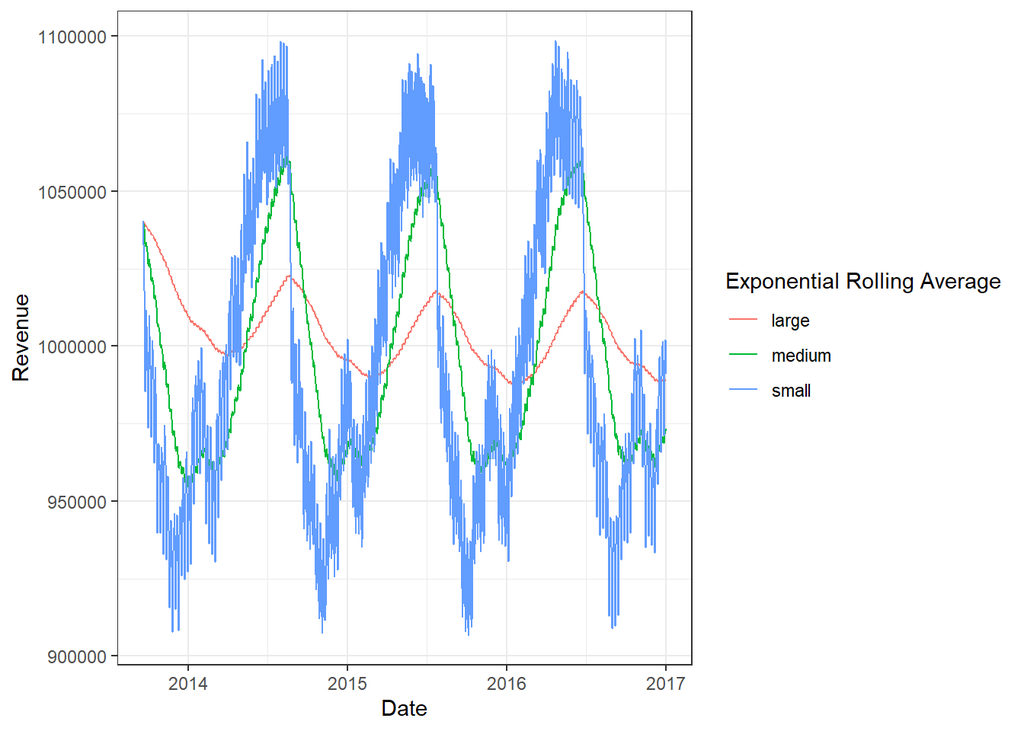

```r
# choose the span
revenue_daily <- revenue_daily %>%
    mutate(small = movavg(sum.revenue, 10, type = "e"),
           medium = movavg(sum.revenue, 100, type = "e"),
           large = movavg(sum.revenue, 500, type = "e"))

era_compare <- revenue_daily %>%
    pivot_longer(names_to = "era_key",
                 values_to = "era_value",
                 cols = c(small, medium, large))

ggplot(era_compare, aes(x=date,
                        y = era_value,
                        color = era_key)) +
    geom_line() +
    theme_bw() +
    labs(x="Date", y="Revenue") +
    scale_color_discrete(name = "Exponential Rolling Average")
```

```r
revenue$date.month <- format(revenue$date, "%Y-%m")
revenue_group <- revenue %>%
    group_by(date.month, device, gender) %>%
    summarise(revenue = sum(revenue)) %>%
    kable(col.names = c("Month","Device","Gender","Revenue"))
```

## The Design and Application of A/B Testing

Concepts of A/B testing

- Response variable
  - Either a KPI or related to a KPI
- Factors & variants
  - Facotrs: the type of variable you are changing (i.e. the paywall color)
  - Variants: particular changes you are testing (i.e. a red versus blue paywall)
- Experimental unit
  - The smallest unit you are measuring the change over (i.e. individual users; user-days)
- Test sensitivity
  - What size of impact is meaningful to detect?
  - Sensitivity: the minimum level of change we want to detect in the test Try out different values (i.e. 1%, 10% lift in revenue per user)
- Data variability
  - Does the amount spent vary a lot among users? If not, then it will be easier to detect a change
  - Good to contextualize standard deviataion by computing mean/standard deviation
- Formulas
  - Statistical power: probability of finding a statistically significant result when the Null hypothesis is false
    - The bigger the sample size, the larger the power
    - The bigger the confidence interval, the smaller the power
  - Confidence level: probability of not making Type I error (higher the value, larger test sample needed)
  - Test sensitivity
  - P-value: probability of obtaining an effect at least as extreme as the one in the sample, given that the null hypothesis is true

```r
get_power <- function(n, p1, p2, ci){
    alpha = 1-ci
    qu = qnorm(1-alpha/2) # given an area, find the boundary value that determines this area
    diff = abs(p2 - p1)
    bp = (p1+p2)/2

    v1 = p1*(1-p1)
    v2 = p2*(1-p2)
    bv = bp*(1-bp)

    power_part_one = pnorm((n^0.5 * diff - qu * (2 * bv)^0.5) / (v1+v2)^0.5)
    power_part_two = 1 - pnorm((n^0.5 * diff + qu * (2 * bv)^0.5) / (v1+v2)^0.5)

    power = power_part_one + power_part_two
    return(power)
}
```

```r
get_power(1000, 0.1, 0.12, 0.95)   #  0.29808032538146
```

```
## [1] 0.2980803
```

```r
get_power(2000, 0.1, 0.12, 0.95)   #  0.524515256115834
```

```
## [1] 0.5245153
```

```r
get_power(1000, 0.1, 0.12, 0.8)    #  0.5621010118690234
```

```
## [1] 0.562101
```

```r
get_sample_size <- function(power, p1, p2, ci, max_n=1000000){
    n=1
    while (n <= max_n) {
        tmp_power = get_power(n, p1, p2, ci)
        if (tmp_power >= power){
            return(n)
        } else {
            n = n+100
        }
    }
    return("Increase Max N Value")
}
```

```r
# Trial 1
conversion_rate = 0.03
power = 0.8
ci = 0.9
lift = 0.1
conversion_rate_p2 = conversion_rate * (1 + lift)
get_sample_size(power, conversion_rate, conversion_rate_p2, ci) # 42001
```

```
## [1] 42001
```

```r
# Trial 2
conversion_rate = 0.03
power = 0.95
ci = 0.9
lift = 0.1
conversion_rate_p2 = conversion_rate * (1 + lift)
get_sample_size(power, conversion_rate, conversion_rate_p2, ci) # 73401
```

```
## [1] 73401
```

## Analyzing AB Testing Results

Steps to take

- Check the group sizes
- Check if groups have similar demographics
- Check if the result is statistically significant

```r
get_pvalue <- function(con_conv, test_conv, con_size, test_size){
    lift = -abs(test_conv - con_conv)
    scale_one = con_conv * (1-con_conv) * (1/con_size)
    scale_two = test_conv * (1-test_conv) * (1/test_size)
    scale_val = (scale_one + scale_two)^0.5
    p_value = 2 * pnorm(lift, 0, scale_val)
    return(p_value)
}
```

```r
# Trial 1
con_conv = 0.034351
test_conv = 0.041984
con_size = 48236
test_size = 49867
get_pvalue(con_conv, test_conv, con_size, test_size)   # 4.257297485586909e-10
```

```
## [1] 4.257297e-10
```

```r
# Trial 2
con_conv = 0.034351
test_conv = 0.041984
con_size = 48
test_size = 49
get_pvalue(con_conv, test_conv, con_size, test_size)  # 0.8443
```

```
## [1] 0.8443709
```

```r
get_ci <- function(lift, alpha, sd){
    val = abs(qnorm((1-alpha)/2))
    lower = lift - val * sd
    upper = lift + val * sd
    return(list(lower, upper))
}
```

```r
# Trial 1
test_conv = 0.102005
con_conv = 0.090965
test_size = 56350
con_size = 58583
lift_mean = test_conv - con_conv
lift_variance = (1 - test_conv) * test_conv / test_size + (1 - con_conv) * con_conv / con_size
lift_sd = lift_variance^0.5
get_ci(lift_mean, 0.95, lift_sd) # (0.007624337671217316, 0.014455662328782672)
```

```
## [[1]]
## [1] 0.007624338
##
## [[2]]
## [1] 0.01445566
```

```r
# Trial 2
test_conv = 0.102005
con_conv = 0.090965
test_size = 563
con_size = 585
lift_mean = test_conv - con_conv
lift_variance = (1 - test_conv) * test_conv / test_size + (1 - con_conv) * con_conv / con_size
lift_sd = lift_variance**0.5
get_ci(lift_mean, 0.95, lift_sd) # (-0.023135997406420666, 0.045215997406420655)
```

```
## [[1]]
## [1] -0.023136
##
## [[2]]
## [1] 0.045216
```